# Simple Investment Portfolio Illustration in Shiny

10 Juni 2018

## Investments are not intuitive

Financial investments are not intuitive and there are several aspects to consider when investing one's money. The two most important aspects are

- The expected return
- The associated risk

While the first is still easy to understand the latter is hard to grasp for most layman. This app helps to build more understanding by offering an illustration of a historic investment in Apple stock, SPY (an S&P 500 ETF) and/or cash (short term treasury bills).

## Maximum Drawdown offers an accessible risk measure

In order offer the user an accessible risk measure maximum drawdown is used. Current drawdown of a portfolio is its historic maximum value (since setting up the portfolio) minus its current value. This number is always positive and zero if the current value is also the maximum the portfolio has ever obtained.

Maximum drawdown is the maximum current drawdown value over the period of consideration. It is a more intuitive risk measure as it is related to the *regret* that one might feel when monitoring one's investment. When one sees that the investment is down xx% from what it once was, a natural question is whether one terminate the investment. An investors risk tolerance is therefore translated into some sort of regret tolerance.

## The Quantmod package offers easy access to historic market data

In order to illustrate any financial situation one needs data. The `Quantmod` package offers an easy way to import historical price data from yahoo finance.

```
##            SPY.Open SPY.High SPY.Low SPY.Close SPY.Volume SPY.Adjusted
## 2007-01-03   142.25   142.86  140.57    141.37   94807600     112.1707
## 2007-01-04   141.23   142.05  140.61    141.67   69620600     112.4087
## 2007-01-05   141.33   141.40  140.38    140.54   76645300     111.5121
## 2007-01-08   140.82   141.41  140.25    141.19   71655000     112.0279
## 2007-01-09   141.31   141.60  140.40    141.07   75680100     111.9327
## 2007-01-10   140.58   141.57  140.30    141.54   72428000     112.3056
```

## Adjusted closing prices can be used to simulate protfolios

Example of a hypothetical $100 investment in SPY:

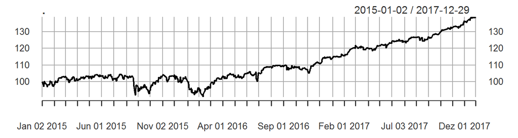

```r
SPY$SPY.Adjusted %>% window(start=as.Date("2015-01-01")
                            ,end=as.Date("2017-12-31")) %>%
  {./as.double(.[1])*100} %>% plot
```